# Distractor Interference under Distribution Change

2025-09-03

## Overview

In this study, we conducted an eye-tracking experiment using the additional singleton visual search paradigm with two groups (experiments). In the unequal-distribution group (Experiment 1), a salient distractor appeared four times more frequently in one region (frequent) than the other (rare) during the first half of the experiment. In the second half, both regions had equal distractor frequency, matching the rare region from the first half. In the equal-distribution group (Experiment 2), distractors appeared with equal frequency in both regions throughout. The design of the unequal group closely mirrored Experiment 2 of the Valsecchi and Turatto (2021) study (with some minor differences, see the methods section for details). The first half of the experiment is a conceptual replication of our previous study (Allenmark et al., 2022) but used their stimulus parameters (different-dimension distractor, random shape and color swapping) across both groups to ensure comparability.

Key analyses: - Baseline RT (distractor absent trials) and Error rates  
- Distractor interference effects - Mixed ANOVA tests for all measures - three distinct phases of visual search based on eye movements.

Three key phases of visual search were defined based on eye movement data:

1. **First Target Fixation (ftf_RT)**: Time from trial start until initial target fixation
2. **Middle Target Fixation (mtf_RT)**: Time between initial and final target fixations
3. **Response Phase (resp_RT)**: Time from final target fixation until decision response

The key research questions focus on how local and global statistical learning of distractor locations affects interference patterns across these temporal phases, comparing: - **Equal group**: Distractors appear equally often in all regions - **Unequal rare**: Distractors appear infrequently in this specific region (unequal group) - **Unequal frequent**: Distractors appear frequently in this region (unequal group)

## Data Loading and Preprocessing

```r
# Load preprocessed data (RT)
data <- read.csv('data/data.csv', row.names = 1)

# Keep only correct responses for RT analysis
analysis_data <- data |>
  filter(SearchResponse.corr == 1 & !outlier)

# Display data summary
cat("=== DATA SUMMARY ===\n")
```

```
## === DATA SUMMARY ===
```

```r
cat("- Total trials:", nrow(data), "\n")
```

```
## - Total trials: 46080
```

```r
cat("- Analysis trials:", nrow(analysis_data),
    sprintf("(%.1f%%)\n", nrow(analysis_data)/nrow(data)*100))
```

```
## - Analysis trials: 43438 (94.3%)
```

```r
cat("- Participants:", length(unique(analysis_data$participant)), "\n")
```

```
## - Participants: 48
```

```r
# Group and block type counts
cat("- Groups:\n")
```

```
## - Groups:
```

```r
print(table(analysis_data$distr_cond))
```

```
##
##   equal unequal
##   21830   21608
```

```r
cat("- Block types:\n")
```

```
## - Block types:
```

```r
print(table(analysis_data$blkType))
```

```
##
##  After change Before change
##         22007         21431
```

```r
# Load the preprocessed RT data from eye-tracking analysis
rt_data_both_phases <- read.csv("data/rt_data_both_phases.csv")

# Verify data structure
str(rt_data_both_phases)
```

```
## 'data.frame':    1152 obs. of  6 variables:
##  $ blkType    : chr  "Before change" "Before change" "Before change" "Before change" ...
##  $ DistCond   : chr  "Absent" "Absent" "Absent" "Absent" ...
##  $ distr_cond : chr  "equal" "equal" "equal" "equal" ...
##  $ participant: chr  "E2_01_JM" "E2_02_YN" "E2_03_XY" "E2_04_ER" ...
##  $ rt_type    : chr  "rt" "rt" "rt" "rt" ...
##  $ rt         : num  998 877 1523 862 1701 ...
```

```r
head(rt_data_both_phases)
```

```
##         blkType DistCond distr_cond participant rt_type        rt
## 1 Before change   Absent      equal    E2_01_JM      rt  997.6752
## 2 Before change   Absent      equal    E2_02_YN      rt  877.2918
## 3 Before change   Absent      equal    E2_03_XY      rt 1523.1106
## 4 Before change   Absent      equal    E2_04_ER      rt  862.3663
## 5 Before change   Absent      equal    E2_05_YS      rt 1701.1732
## 6 Before change   Absent      equal    E2_06_ER      rt 1952.6565
```

```r
# Check unique conditions
unique(rt_data_both_phases$DistCond)
```

```
## [1] "Absent"      "Freq. dist." "Rare dist."
```

```r
unique(rt_data_both_phases$distr_cond)
```

```
## [1] "equal"   "unequal"
```

```r
unique(rt_data_both_phases$blkType)
```

```
## [1] "Before change" "After change"
```

```r
unique(rt_data_both_phases$rt_type)
```

```
## [1] "rt"      "ftf_RT"  "mtf_RT"  "resp_RT"
```

## 1. Baseline Response Times (Distractor Absent)

Analyze baseline response times with: - **Between-subject factor**: Group (equal vs. unequal) - **Within-subject factor**: Block Type (Before change vs. After change)

```r
# Calculate baseline RT (distractor absent trials)
baseline_rt <- analysis_data |>
  filter(DistCond == "Absent") |>
  group_by(participant, distr_cond, blkType) |>
  summarise(rt_ms = mean(SearchResponse.rt) * 1000, .groups = "drop")

# Summary statistics
cat("=== BASELINE RT SUMMARY ===\n")
```

```
## === BASELINE RT SUMMARY ===
```

```r
rt_summary <- baseline_rt |>
  group_by(distr_cond, blkType) |>
  summarise(
    Mean_RT = mean(rt_ms),
    SD_RT = sd(rt_ms),
    N = n(),
    SEM = sd(rt_ms) / sqrt(n()),
    .groups = "drop"
  )

print(kable(rt_summary, digits = 1))
```

```
##
##
## |distr_cond |blkType       | Mean_RT| SD_RT|  N|  SEM|
## |:----------|:-------------|-------:|-----:|--:|----:|
## |equal      |After change  |   960.2| 259.3| 24| 52.9|
## |equal      |Before change |  1108.6| 318.9| 24| 65.1|
## |unequal    |After change  |  1017.6| 251.1| 24| 51.2|
## |unequal    |Before change |  1141.7| 285.7| 24| 58.3|
```

```r
# Mixed ANOVA for baseline RT
baseline_rt_clean <- baseline_rt |>
  mutate(
    participant = as.factor(participant),
    distr_cond = as.factor(distr_cond),
    blkType = as.factor(blkType)
  )

baseline_rt_anova <- ezANOVA(
  data = baseline_rt_clean,
  dv = rt_ms,
  wid = participant,
  within = blkType,
  between = distr_cond,
  detailed = TRUE
)

cat("\n=== MIXED ANOVA: BASELINE RT ===\n")
```

```
##
## === MIXED ANOVA: BASELINE RT ===
```

```r
cat("DV: Response Time (ms)\n")
```

```
## DV: Response Time (ms)
```

```r
cat("Within-subject factor: blkType (Before change vs. After change)\n")
```

```
## Within-subject factor: blkType (Before change vs. After change)
```

```r
cat("Between-subject factor: distr_cond (equal vs. unequal)\n\n")
```

```
## Between-subject factor: distr_cond (equal vs. unequal)
```

```r
print(kable(baseline_rt_anova$ANOVA, digits = 4))
```

```
##
##
## |Effect             | DFn| DFd|          SSn|       SSd|        F|      p|p<.05 |    ges|
## |:------------------|---:|---:|------------:|---------:|--------:|------:|:-----|------:|
## |(Intercept)        |   1|  46| 1.072565e+08| 6794897.6| 726.1037| 0.0000|*     | 0.9370|
## |distr_cond         |   1|  46| 4.914932e+04| 6794897.6|   0.3327| 0.5669|      | 0.0068|
## |blkType            |   1|  46| 4.452956e+05|  417453.6|  49.0680| 0.0000|*     | 0.0582|
## |distr_cond:blkType |   1|  46| 3.548904e+03|  417453.6|   0.3911| 0.5348|      | 0.0005|
```

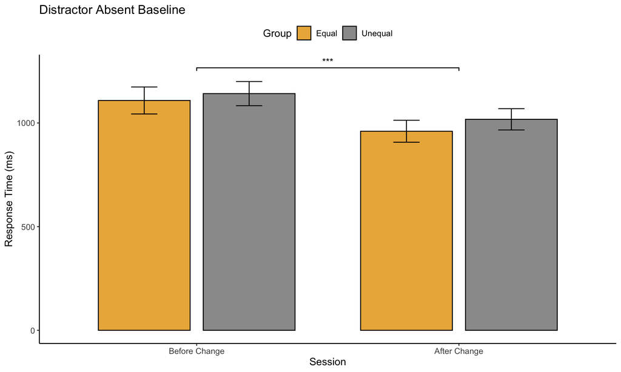

```r
# Create baseline RT visualization
baseline_rt_plot <- baseline_rt |>
  mutate(
    Group = str_to_title(distr_cond),
    Group = factor(Group, levels = c("Equal", "Unequal")),
    Session = case_when(
      blkType == "Before change" ~ "Before Change",
      blkType == "After change" ~ "After Change"
    ),
    Session = factor(Session, levels = c("Before Change", "After Change"))
  ) |>
  ggplot(aes(x = Session, y = rt_ms, fill = Group)) +
  stat_summary(fun = mean, geom = "bar", position = position_dodge(0.8),
               alpha = 0.8, color = 'black', width = 0.7) +
  stat_summary(fun.data = mean_se, geom = "errorbar",
               position = position_dodge(0.8), width = 0.2) +
  geom_signif(comparisons = list(c("Before Change", "After Change")),
              annotations = "***", y_position = 1200, tip_length = 0.01) +
  scale_fill_manual(values = colors, breaks = c("Equal", "Unequal"),
    limits = c("Equal", "Unequal")) +
  labs(
    title = "Distractor Absent Baseline",
    y = "Response Time (ms)",
    x = "Session"
  ) +
  theme(legend.position = 'top')

baseline_rt_plot
```

## 2. Error Rates (Distractor Absent)

```r
# Calculate error rates (distractor absent trials)
error_rates <- data |>
  filter(DistCond == "Absent" & !is.na(SearchResponse.rt)) |>
  group_by(participant, distr_cond, blkType) |>
  summarise(error_rate = 1 - mean(SearchResponse.corr), .groups = "drop")

# Summary statistics
cat("=== ERROR RATE SUMMARY ===\n")
```

```
## === ERROR RATE SUMMARY ===
```

```r
error_summary <- error_rates |>
  group_by(distr_cond, blkType) |>
  summarise(
    Mean_Error = mean(error_rate),
    SD_Error = sd(error_rate),
    N = n(),
    SEM = sd(error_rate) / sqrt(n()),
    .groups = "drop"
  )

print(kable(error_summary, digits = 4))
```

```
##
##
## |distr_cond |blkType       | Mean_Error| SD_Error|  N|    SEM|
## |:----------|:-------------|----------:|--------:|--:|------:|
## |equal      |After change  |     0.0259|   0.0256| 24| 0.0052|
## |equal      |Before change |     0.0279|   0.0260| 24| 0.0053|
## |unequal    |After change  |     0.0247|   0.0236| 24| 0.0048|
## |unequal    |Before change |     0.0292|   0.0308| 24| 0.0063|
```

```r
# Mixed ANOVA for error rates
error_rates_clean <- error_rates |>
  mutate(
    participant = as.factor(participant),
    distr_cond = as.factor(distr_cond),
    blkType = as.factor(blkType)
  )

error_rate_anova <- ezANOVA(
  data = error_rates_clean,
  dv = error_rate,
  wid = participant,
  within = blkType,
  between = distr_cond,
  detailed = TRUE
)

cat("\n=== MIXED ANOVA: ERROR RATES ===\n")
```

```
##
## === MIXED ANOVA: ERROR RATES ===
```

```r
cat("DV: Error Rate\n")
```

```
## DV: Error Rate
```

```r
cat("Within-subject factor: blkType (Before change vs. After change)\n")
```

```
## Within-subject factor: blkType (Before change vs. After change)
```

```r
cat("Between-subject factor: distr_cond (equal vs. unequal)\n\n")
```

```
## Between-subject factor: distr_cond (equal vs. unequal)
```

```r
print(kable(error_rate_anova$ANOVA, digits = 4))
```

```
##
##
## |Effect             | DFn| DFd|    SSn|    SSd|       F|      p|p<.05 |    ges|
## |:------------------|---:|---:|------:|------:|-------:|------:|:-----|------:|
## |(Intercept)        |   1|  46| 0.0697| 0.0575| 55.6976| 0.0000|*     | 0.5163|
## |distr_cond         |   1|  46| 0.0000| 0.0575|  0.0000| 0.9974|      | 0.0000|
## |blkType            |   1|  46| 0.0002| 0.0077|  1.4807| 0.2299|      | 0.0038|
## |distr_cond:blkType |   1|  46| 0.0000| 0.0077|  0.2082| 0.6503|      | 0.0005|
```

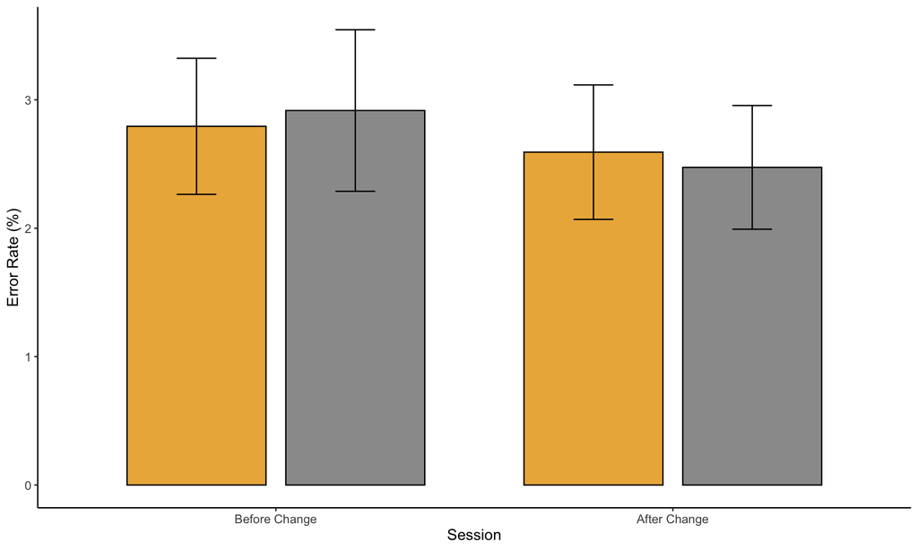

```r
# Create error rate visualization
error_rate_plot <- error_rates |>
  mutate(
    Group = str_to_title(distr_cond),
    Session = case_when(
      blkType == "Before change" ~ "Before Change",
      blkType == "After change" ~ "After Change"
    ),
    Session = factor(Session, levels = c("Before Change", "After Change")),
    error_rate_pct = error_rate * 100
  ) |>
  ggplot(aes(x = Session, y = error_rate_pct, fill = Group)) +
  stat_summary(fun = mean, geom = "bar", position = position_dodge(0.8),
               alpha = 0.8, color = "black", width = 0.7) +
  stat_summary(fun.data = mean_se, geom = "errorbar",
               position = position_dodge(0.8), width = 0.2) +
  scale_fill_manual(values = colors) +
  scale_y_continuous(limits = c(0, NA)) +
  labs(
    y = "Error Rate (%)",
    x = "Session",
    fill = "Group"
  ) +
  theme(legend.position = "")

print(error_rate_plot)
```

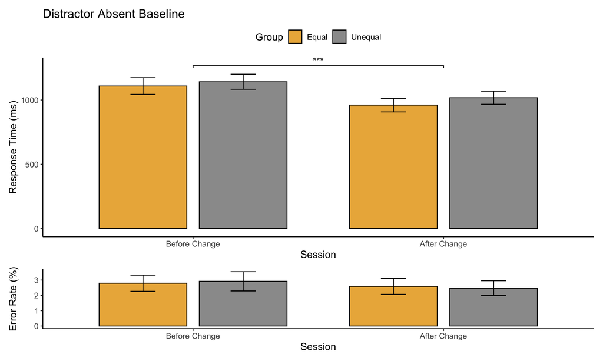

```r
# Combine baseline plots
combined_baseline <- baseline_rt_plot / error_rate_plot +
  plot_layout(heights = c(3, 1))

ggsave("./Figures/baseline_combined.png", combined_baseline,
       width = 8, height = 6, dpi = 300)

combined_baseline
```

## 3. Distractor Interference Analysis

Calculate and analyze distractor interference effects: - **Equal group**: Average interference (Frequent + Rare) / 2 - Absent - **Unequal group**: Separate frequent and rare region interference - Additional statistics comparing regions within unequal group and between groups

```r
# Calculate RT by all distractor conditions for detailed interference analysis
rt_by_condition <- analysis_data |>
  group_by(participant, distr_cond, blkType, DistCond) |>
  summarise(rt_ms = mean(SearchResponse.rt) * 1000, .groups = "drop") |>
  pivot_wider(names_from = DistCond, values_from = rt_ms)

# Calculate interference measures
interference_detailed <- rt_by_condition |>
  mutate(
    # Average interference for equal group
    avg_interference = (`Freq. dist.` + `Rare dist.`) / 2 - Absent,
    # Individual interference effects for unequal group
    rare_interference = `Rare dist.` - Absent,
    freq_interference = `Freq. dist.` - Absent
  )

cat("=== DETAILED INTERFERENCE SUMMARY ===\n")
```

```
## === DETAILED INTERFERENCE SUMMARY ===
```

```r
# Equal group - average interference
equal_interference <- interference_detailed |>
  filter(distr_cond == "equal") |>
  group_by(blkType) |>
  summarise(
    Mean = mean(avg_interference),
    SD = sd(avg_interference),
    N = n(),
    SEM = sd(avg_interference) / sqrt(n()),
    .groups = "drop"
  )

cat("Equal Group - Average Interference:\n")
```

```
## Equal Group - Average Interference:
```

```r
print(kable(equal_interference, digits = 1))
```

```
##
##
## |blkType       |  Mean|    SD|  N|  SEM|
## |:-------------|-----:|-----:|--:|----:|
## |After change  | 247.1| 121.7| 24| 24.8|
## |Before change | 258.5|  76.7| 24| 15.6|
```

```r
# Unequal group - separate regions
unequal_interference <- interference_detailed |>
  filter(distr_cond == "unequal") |>
  group_by(blkType) |>
  summarise(
    Freq_Mean = mean(freq_interference),
    Freq_SD = sd(freq_interference),
    Freq_N = n(),
    Freq_SEM = sd(freq_interference) / sqrt(n()),
    Rare_Mean = mean(rare_interference),
    Rare_SD = sd(rare_interference),
    Rare_N = n(),
    Rare_SEM = sd(rare_interference) / sqrt(n()),
    .groups = "drop"
  )

cat("\nUnequal Group - Regional Interference:\n")
```

```
##
## Unequal Group - Regional Interference:
```

```r
print(kable(unequal_interference, digits = 1))
```

```
##
##
## |blkType       | Freq_Mean| Freq_SD| Freq_N| Freq_SEM| Rare_Mean| Rare_SD| Rare_N| Rare_SEM|
## |:-------------|---------:|-------:|------:|--------:|---------:|-------:|------:|--------:|
## |After change  |     185.9|    91.0|     24|     18.6|     229.5|     108|     24|     22.1|
## |Before change |     164.3|    66.4|     24|     13.6|     194.3|     101|     24|     20.6|
```

```r
cat("=== ADDITIONAL INTERFERENCE STATISTICS ===\n\n")
```

```
## === ADDITIONAL INTERFERENCE STATISTICS ===
```

```r
# 1. Equal group vs. Unequal rare region comparison
equal_avg <- interference_detailed |> filter(distr_cond == "equal")
unequal_rare <- interference_detailed |> filter(distr_cond == "unequal")

# Create comparison dataset
comparison_data <- bind_rows(
  equal_avg |>
    select(participant, blkType, interference = avg_interference) |>
    mutate(condition = "Equal_Avg"),
  unequal_rare |>
    select(participant, blkType, interference = rare_interference) |>
    mutate(condition = "Unequal_Rare")
) |>
  mutate(
    participant = as.factor(participant),
    blkType = as.factor(blkType),
    condition = as.factor(condition)
  )

# Mixed ANOVA: Equal avg vs. Unequal rare
comparison_anova <- ezANOVA(
  data = comparison_data,
  dv = interference,
  wid = participant,
  within = blkType,
  between = condition,
  detailed = TRUE
)

cat("1. MIXED ANOVA: EQUAL AVG vs. UNEQUAL RARE INTERFERENCE\n")
```

```
## 1. MIXED ANOVA: EQUAL AVG vs. UNEQUAL RARE INTERFERENCE
```

```r
print(kable(comparison_anova$ANOVA, digits = 4))
```

```
##
##
## |Effect            | DFn| DFd|         SSn|      SSd|        F|      p|p<.05 |    ges|
## |:-----------------|---:|---:|-----------:|--------:|--------:|------:|:-----|------:|
## |(Intercept)       |   1|  46| 5182617.429| 767171.5| 310.7524| 0.0000|*     | 0.8411|
## |condition         |   1|  46|   40183.171| 767171.5|   2.4094| 0.1275|      | 0.0394|
## |blkType           |   1|  46|    3408.037| 212080.1|   0.7392| 0.3944|      | 0.0035|
## |condition:blkType |   1|  46|   13049.816| 212080.1|   2.8305| 0.0993|      | 0.0132|
```

```r
cat("\n")
```

```r
# 2. Within unequal group: Frequent vs. Rare region comparison
unequal_long <- unequal_rare |>
  select(participant, blkType, freq_interference, rare_interference) |>
  pivot_longer(cols = c(freq_interference, rare_interference),
               names_to = "region_type", values_to = "interference") |>
  mutate(
    region = case_when(
      region_type == "freq_interference" ~ "Frequent",
      region_type == "rare_interference" ~ "Rare"
    ),
    participant = as.factor(participant),
    blkType = as.factor(blkType),
    region = as.factor(region)
  )

# rm ANOVA: Frequent vs. Rare within unequal group
unequal_anova <- ezANOVA(
  data = unequal_long,
  dv = interference,
  wid = participant,
  within = .(blkType, region),
  detailed = TRUE
)

cat("2. RM ANOVA: FREQUENT vs. RARE REGIONS (UNEQUAL GROUP)\n")
```

```
## 2. RM ANOVA: FREQUENT vs. RARE REGIONS (UNEQUAL GROUP)
```

```r
print(kable(unequal_anova$ANOVA, digits = 4))
```

```
##
##
## |Effect         | DFn| DFd|         SSn|       SSd|        F|      p|p<.05 |    ges|
## |:--------------|---:|---:|-----------:|---------:|--------:|------:|:-----|------:|
## |(Intercept)    |   1|  23| 3593727.564| 542158.77| 152.4567| 0.0000|*     | 0.8188|
## |blkType        |   1|  23|   19378.980| 176214.67|   2.5294| 0.1254|      | 0.0238|
## |region         |   1|  23|   32531.869|  33798.96|  22.1378| 0.0001|*     | 0.0393|
## |blkType:region |   1|  23|    1115.946|  43047.85|   0.5962| 0.4479|      | 0.0014|
```

```r
cat("\n")
```

```r
# 3. Simple effect tests for specific comparisons
cat("3. POST-HOC COMPARISONS\n")
```

```
## 3. POST-HOC COMPARISONS
```

```r
cat(rep("-", 30), "\n")
# Before change: Equal avg vs. Unequal rare
equal_before <- equal_avg |>
  filter(blkType == "Before change") |>
  pull(avg_interference)
unequal_rare_before <- unequal_rare |>
  filter(blkType == "Before change") |>
  pull(rare_interference)

test1 <- t.test(equal_before, unequal_rare_before, var.equal = FALSE)
cat("Before change - Equal avg vs. Unequal rare:\n")
```

```
## Before change - Equal avg vs. Unequal rare:
```

```r
cat(sprintf("Equal: M = %.1f ms, Unequal rare: M = %.1f ms\n",
           mean(equal_before), mean(unequal_rare_before)))
```

```
## Equal: M = 258.5 ms, Unequal rare: M = 194.3 ms
```

```r
cat(sprintf("t(%.1f) = %.3f, p = %.3f, d = %.3f\n\n",
           test1$parameter, test1$statistic, test1$p.value,
           (mean(equal_before) - mean(unequal_rare_before)) /
           sqrt((var(equal_before) + var(unequal_rare_before))/2)))
```

```
## t(42.9) = 2.481, p = 0.017, d = 0.716
```

```r
# Before change: Unequal frequent vs. rare (paired)
unequal_freq_before <- unequal_rare |>
  filter(blkType == "Before change") |>
  pull(freq_interference)

test2 <- t.test(unequal_freq_before, unequal_rare_before, paired = TRUE)
cat("Before change - Unequal freq vs. rare (paired):\n")
```

```
## Before change - Unequal freq vs. rare (paired):
```

```r
cat(sprintf("Frequent: M = %.1f ms, Rare: M = %.1f ms\n",
           mean(unequal_freq_before), mean(unequal_rare_before)))
```

```
## Frequent: M = 164.3 ms, Rare: M = 194.3 ms
```

```r
cat(sprintf("t(%.0f) = %.3f, p = %.3f\n\n",
           test2$parameter, test2$statistic, test2$p.value))
```

```
## t(23) = -2.379, p = 0.026
```

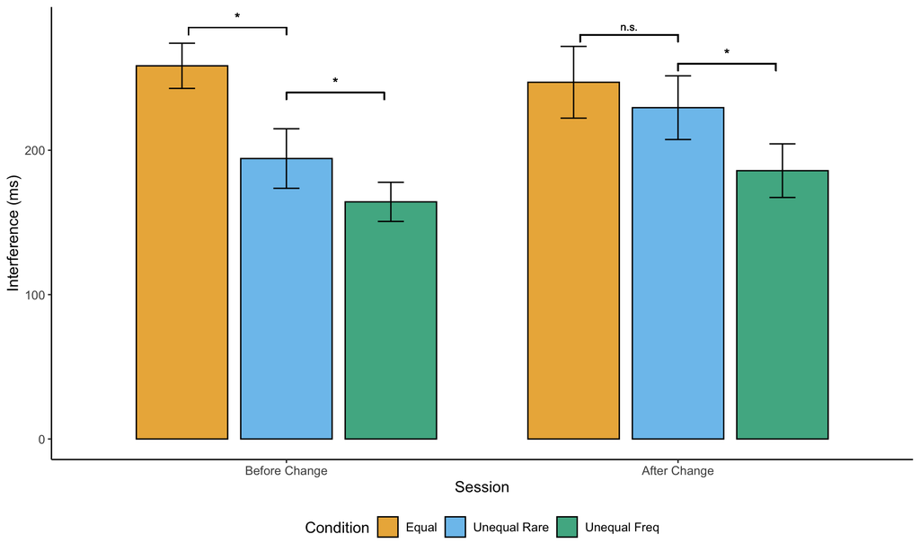

```r
# Visualize detailed distractor interference
plot_data <- bind_rows(
  # Equal group - average interference
  interference_detailed |>
    filter(distr_cond == "equal") |>
    select(participant, blkType, interference = avg_interference) |>
    mutate(Condition = "Equal"),

  # Unequal group - rare region
  interference_detailed |>
    filter(distr_cond == "unequal") |>
    select(participant, blkType, interference = rare_interference) |>
    mutate(Condition = "Unequal Rare"),

  # Unequal group - frequent region
  interference_detailed |>
    filter(distr_cond == "unequal") |>
    select(participant, blkType, interference = freq_interference) |>
    mutate(Condition = "Unequal Freq")
) |>
  mutate(
    Session = case_when(
      blkType == "Before change" ~ "Before Change",
      blkType == "After change" ~ "After Change"
    ),
    Session = factor(Session, levels = c("Before Change", "After Change")),
    Condition = factor(Condition, levels = c("Equal", "Unequal Rare", "Unequal Freq"))
  )

interference_plot <- plot_data |>
  ggplot(aes(x = Session, y = interference, fill = Condition)) +
  stat_summary(fun = mean, geom = "bar", position = position_dodge(0.8),
               alpha = 0.8, color = "black", width = 0.7) +
  stat_summary(fun.data = mean_se, geom = "errorbar",
               position = position_dodge(0.8), width = 0.2) +
  geom_signif(data = subset(plot_data, Session == "Before Change"),
              aes(xmin = 0.75, xmax = 1.0, annotations = "*", y_position = 285),
              manual = TRUE, tip_length = 0.01, textsize = 4) +
  geom_signif(data = subset(plot_data, Session == "After Change"),
              aes(xmin = 1.75, xmax = 2.0, annotations = "n.s.", y_position = 280),
              manual = TRUE, tip_length = 0.01, textsize = 3) +
  geom_signif(data = subset(plot_data, Session == "Before Change"),
              aes(xmin = 1.0, xmax = 1.25, annotations = "*", y_position = 240),
              manual = TRUE, tip_length = 0.01, textsize = 4) +
  geom_signif(data = subset(plot_data, Session == "After Change"),
              aes(xmin = 2.0, xmax = 2.25, annotations = "*", y_position = 260),
              manual = TRUE, tip_length = 0.01, textsize = 4) +
  scale_fill_manual(values = colors) +
  scale_y_continuous(limits = c(0, NA)) +
  labs(
    y = "Interference (ms)",
    x = "Session",
    fill = "Condition"
  )

ggsave("./Figures/interference_detailed.png", interference_plot,
       width = 8, height = 4, dpi = 300)

print(interference_plot)
```

## 4. Phases of Visual Search Analysis

### Data Transformation for Interference Analysis

```r
# Calculate distractor interference by comparing distractor-present vs distractor-absent conditions
int_pc_data <- rt_data_both_phases %>%
  spread(DistCond, rt) %>%
  mutate(
    # Average interference: mean of rare and frequent distractors minus absent baseline
    avg_int = (`Freq. dist.` + `Rare dist.`)/2 - Absent,

    # Probability cueing effect: difference between rare and frequent distractor interference
    pc = `Rare dist.` - `Freq. dist.`,

    # Individual region interference effects
    rare_int = `Rare dist.` - Absent,
    freq_int = `Freq. dist.` - Absent
  ) %>%
  select(-c(Absent, `Freq. dist.`, `Rare dist.`))

# Transform to long format for analysis and visualization
int_data_both <- int_pc_data %>%
  group_by(blkType, distr_cond, rt_type) %>%
  select(-c(pc)) %>%
  gather("int_type", "int", -c("distr_cond", "rt_type", "participant", "blkType"))

# Create summary statistics for visualization
sint_data_both <- int_data_both %>%
  filter(
    (int_type == "avg_int" & distr_cond == "equal") |
    (int_type != "avg_int" & distr_cond == "unequal")
  ) %>%
  group_by(blkType, distr_cond, rt_type, int_type) %>%
  summarize(
    mint = mean(int),
    sint = sd(int)/sqrt(n()-1),
    .groups = "drop"
  )

head(sint_data_both)
```

```
## # A tibble: 6 × 6
##   blkType      distr_cond rt_type int_type  mint  sint
##   <chr>        <chr>      <chr>   <chr>    <dbl> <dbl>
## 1 After change equal      ftf_RT  avg_int  167.   16.6
## 2 After change equal      mtf_RT  avg_int   47.1  11.9
## 3 After change equal      resp_RT avg_int   48.3  10.3
## 4 After change equal      rt      avg_int  262.   25.8
## 5 After change unequal    ftf_RT  freq_int 133.   14.8
## 6 After change unequal    ftf_RT  rare_int 182.   17.7
```

## 5. Visualization of Distractor Interference across Phases

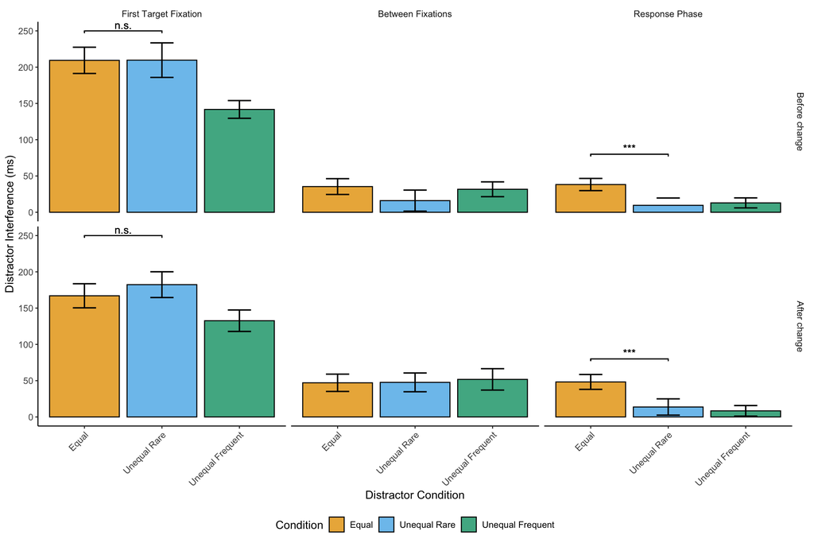

```r
# Create visualization with white background and proper ordering
int_phases_data <- sint_data_both %>%
  filter(rt_type != "rt") %>%  # Exclude total RT, focus on phase-specific measures
  mutate(
    # Create meaningful condition labels for visualization
    condition_combo = case_when(
      int_type == "avg_int" & distr_cond == "equal" ~ "Equal",
      int_type == "rare_int" & distr_cond == "unequal" ~ "Unequal Rare",
      int_type == "freq_int" & distr_cond == "unequal" ~ "Unequal Frequent"
    ),
    # Ensure proper ordering
    condition_combo = factor(condition_combo,
                            levels = c("Equal", "Unequal Rare", "Unequal Frequent")),
    # Clean phase labels
    rt_type = factor(rt_type,
                    levels = c("ftf_RT", "mtf_RT", "resp_RT"),
                    labels = c("First Target Fixation", "Between Fixations", "Response Phase")),
    # Proper ordering for blkType
    blkType = factor(blkType,
                    levels = c("Before change", "After change"))
  )

  int_phases_fig = int_phases_data |>
  ggplot(aes(x = condition_combo, y = mint, fill = condition_combo)) +
  geom_col(color = "black", alpha = 0.8) +
  geom_errorbar(aes(ymin = mint - sint, ymax = mint + sint),
                width = 0.3, size = 0.7) +
  facet_grid(blkType ~ rt_type, scales = "free_y") +
  geom_signif(data = subset(int_phases_data, rt_type == "Response Phase"),
              aes(xmin = 1, xmax = 2.0, annotations = "***", y_position = 80),
              manual = TRUE, tip_length = 0.01, textsize = 4) +
  geom_signif(data = subset(int_phases_data, rt_type == "First Target Fixation"),
              aes(xmin = 1, xmax = 2.0, annotations = "n.s.", y_position = 250),
              manual = TRUE, tip_length = 0.01, textsize = 4) +
  scale_y_continuous(limits = c(0, NA)) +
  theme_classic() +
  theme(
    axis.text.x = element_text(angle = 45, hjust = 1),
    legend.position = "bottom",
    panel.background = element_rect(fill = "white"),
    strip.background = element_blank(),
    text = element_text(size = 12)
  ) +
  labs(
    x = "Distractor Condition",
    y = "Distractor Interference (ms)",
    fill = "Condition"
  ) +
  scale_fill_manual(values = c("Equal" = "#E69F00",
                              "Unequal Rare" = "#56B4E9",
                              "Unequal Frequent" = "#009E73"))
# save the figure
ggsave("./Figures/distractor_interference_phases.png",
       plot = int_phases_fig, width = 8, height = 6, dpi = 300)
print(int_phases_fig)
```

## 6. Statistical Analysis for phases : Mixed-Design ANOVAs

### Data Preparation for ezANOVA

```r
# Prepare data for ANOVA analysis
# Need to create proper data structure for mixed-design ANOVA

# For Equal vs Unequal Rare comparison (between-subjects: equal vs unequal)
equal_rare_data <- int_data_both %>%
  filter(
    (distr_cond == "equal" & int_type == "avg_int") |
    (distr_cond == "unequal" & int_type == "rare_int")
  ) %>%
  mutate(
    # Create group factor for between-subjects comparison
    group = ifelse(distr_cond == "equal", "Equal", "Unequal"),
    # Ensure proper factor ordering
    blkType = factor(blkType, levels = c("Before change", "After change")),
    rt_type = factor(rt_type, levels = c("ftf_RT", "mtf_RT", "resp_RT")),
    participant = as.factor(participant)
  )

# For Unequal Rare vs Frequent comparison (within-subjects within unequal group)
unequal_within_data <- int_data_both %>%
  filter(
    distr_cond == "unequal" & int_type %in% c("rare_int", "freq_int")
  ) %>%
  mutate(
    # Create region factor for within-subjects comparison
    region = ifelse(int_type == "rare_int", "Rare", "Frequent"),
    region = factor(region, levels = c("Rare", "Frequent")),
    # Ensure proper factor ordering
    blkType = factor(blkType, levels = c("Before change", "After change")),
    rt_type = factor(rt_type, levels = c("ftf_RT", "mtf_RT", "resp_RT")),
    participant = as.factor(participant)
  )

head(equal_rare_data)
```

```
## # A tibble: 6 × 7
## # Groups:   blkType, distr_cond, rt_type [4]
##   blkType      distr_cond participant rt_type int_type   int group
##   <fct>        <chr>      <fct>       <fct>   <chr>    <dbl> <chr>
## 1 After change equal      E2_01_JM    ftf_RT  avg_int   66.8 Equal
## 2 After change equal      E2_01_JM    mtf_RT  avg_int   69.4 Equal
## 3 After change equal      E2_01_JM    resp_RT avg_int   44.7 Equal
## 4 After change equal      E2_01_JM    <NA>    avg_int  181.  Equal
## 5 After change equal      E2_02_YN    ftf_RT  avg_int  103.  Equal
## 6 After change equal      E2_02_YN    mtf_RT  avg_int   19.9 Equal
```

```r
head(unequal_within_data)
```

```
## # A tibble: 6 × 7
## # Groups:   blkType, distr_cond, rt_type [4]
##   blkType      distr_cond participant rt_type int_type    int region
##   <fct>        <chr>      <fct>       <fct>   <chr>     <dbl> <fct>
## 1 After change unequal    E1_01_GQ    ftf_RT  rare_int  99.8  Rare
## 2 After change unequal    E1_01_GQ    mtf_RT  rare_int   1.72 Rare
## 3 After change unequal    E1_01_GQ    resp_RT rare_int   5.98 Rare
## 4 After change unequal    E1_01_GQ    <NA>    rare_int 107.   Rare
## 5 After change unequal    E1_02_PP    ftf_RT  rare_int 105.   Rare
## 6 After change unequal    E1_02_PP    mtf_RT  rare_int  54.6  Rare
```

### 6.1 First Target Fixation Phase (ftf_RT)

This phase captures the initial search efficiency - how quickly attention finds the target for the first time.

```r
# Analysis 1: Equal vs Unequal Rare (Mixed design: Group x Block Type)
ftf_equal_rare <- equal_rare_data %>% filter(rt_type == "ftf_RT")

#mean interference
ftf_equal_rare |> group_by(group, blkType) |>
  summarize(mean_int = mean(int), sd_int = sd(int), .groups = "drop")
```

```
## # A tibble: 4 × 4
##   group   blkType       mean_int sd_int
##   <chr>   <fct>            <dbl>  <dbl>
## 1 Equal   Before change     209.   86.8
## 2 Equal   After change      167.   79.6
## 3 Unequal Before change     210.  114.
## 4 Unequal After change      182.   85.1
```

```r
ftf_anova1 <- ezANOVA(
  data = ftf_equal_rare,
  dv = int,
  wid = participant,
  between = group,
  within = blkType,
  detailed = TRUE
)

cat("=== FIRST TARGET FIXATION PHASE ===\n\n")
```

```
## === FIRST TARGET FIXATION PHASE ===
```

```r
cat("Analysis 1: Equal vs Unequal Rare\n")
```

```
## Analysis 1: Equal vs Unequal Rare
```

```r
cat("Mixed ANOVA (Group x Block Type)\n")
```

```
## Mixed ANOVA (Group x Block Type)
```

```r
print(ftf_anova1$ANOVA)
```

```
##          Effect DFn DFd         SSn      SSd           F            p p<.05
## 1   (Intercept)   1  46 3542409.726 529569.6 307.7042873 5.270046e-22     *
## 2         group   1  46    1468.314 529569.6   0.1275422 7.226274e-01
## 3       blkType   1  46   29123.190 256410.8   5.2246895 2.692400e-02     *
## 4 group:blkType   1  46    1365.746 256410.8   0.2450143 6.229639e-01
##           ges
## 1 0.818412760
## 2 0.001864647
## 3 0.035729433
## 4 0.001734619
```

```r
cat("\n")
```

```r
# Analysis 2: Unequal Rare vs Frequent (Repeated measures: Region x Block Type)
ftf_unequal_within <- unequal_within_data %>% filter(rt_type == "ftf_RT")

ftf_anova2 <- ezANOVA(
  data = ftf_unequal_within,
  dv = int,
  wid = participant,
  within = .(region, blkType),
  detailed = TRUE
)
# mean interference
ftf_unequal_within |> group_by(region, blkType) |>
  summarize(mean_int = mean(int), sd_int = sd(int), .groups = "drop")
```

```
## # A tibble: 4 × 4
##   region   blkType       mean_int sd_int
##   <fct>    <fct>            <dbl>  <dbl>
## 1 Rare     Before change     210.  114.
## 2 Rare     After change      182.   85.1
## 3 Frequent Before change     142.   58.5
## 4 Frequent After change      133.   70.9
```

```r
cat("Analysis 2: Unequal Rare vs Frequent\n")
```

```
## Analysis 2: Unequal Rare vs Frequent
```

```r
cat("Repeated Measures ANOVA (Region x Block Type)\n")
```

```
## Repeated Measures ANOVA (Region x Block Type)
```

```r
print(ftf_anova2$ANOVA)
```

```
##           Effect DFn DFd         SSn       SSd           F            p p<.05
## 1    (Intercept)   1  23 2664397.367 310053.26 197.6471367 8.822672e-13     *
## 2         region   1  23   83030.102  65535.76  29.1397008 1.747006e-05     *
## 3        blkType   1  23    7938.593 232442.05   0.7855190 3.846320e-01
## 4 region:blkType   1  23    1989.195  53434.47   0.8562168 3.644072e-01
##           ges
## 1 0.801114611
## 2 0.111525303
## 3 0.011859194
## 4 0.002998238
```

```r
cat("\n")
```

### 6.2 Middle Target Fixation Phase (mtf_RT)

This phase captures re-fixation and verification processes between initial and final target fixations.

```r
# Analysis 1: Equal vs Unequal Rare (Mixed design: Group x Block Type)
mtf_equal_rare <- equal_rare_data %>% filter(rt_type == "mtf_RT")

mtf_anova1 <- ezANOVA(
  data = mtf_equal_rare,
  dv = int,
  wid = participant,
  between = group,
  within = blkType,
  detailed = TRUE
)

cat("=== MIDDLE TARGET FIXATION PHASE ===\n\n")
```

```
## === MIDDLE TARGET FIXATION PHASE ===
```

```r
cat("Analysis 1: Equal vs Unequal Rare\n")
```

```
## Analysis 1: Equal vs Unequal Rare
```

```r
cat("Mixed ANOVA (Group x Block Type)\n")
```

```
## Mixed ANOVA (Group x Block Type)
```

```r
print(mtf_anova1$ANOVA)
```

```
##          Effect DFn DFd        SSn      SSd          F            p p<.05
## 1   (Intercept)   1  46 128208.660 204321.9 28.8642550 2.493748e-06     *
## 2         group   1  46   2115.029 204321.9  0.4761670 4.936306e-01
## 3       blkType   1  46  11232.791 133780.3  3.8623657 5.543558e-02
## 4 group:blkType   1  46   2386.760 133780.3  0.8206813 3.697019e-01
##           ges
## 1 0.274942501
## 2 0.006216703
## 3 0.032154788
## 4 0.007009804
```

```r
cat("\n")
```

```r
# Analysis 2: Unequal Rare vs Frequent (Repeated measures: Region x Block Type)
mtf_unequal_within <- unequal_within_data %>% filter(rt_type == "mtf_RT")

mtf_anova2 <- ezANOVA(
  data = mtf_unequal_within,
  dv = int,
  wid = participant,
  within = .(region, blkType),
  detailed = TRUE
)

cat("Analysis 2: Unequal Rare vs Frequent\n")
```

```
## Analysis 2: Unequal Rare vs Frequent
```

```r
cat("Repeated Measures ANOVA (Region x Block Type)\n")
```

```
## Repeated Measures ANOVA (Region x Block Type)
```

```r
print(mtf_anova2$ANOVA)
```

```
##           Effect DFn DFd         SSn       SSd         F            p p<.05
## 1    (Intercept)   1  23 129953.0807 132781.90 22.510001 8.801073e-05     *
## 2         region   1  23   2344.2187  52385.77  1.029230 3.208936e-01
## 3        blkType   1  23  16032.4607 144567.56  2.550687 1.238957e-01
## 4 region:blkType   1  23    796.3678  40622.81  0.450891 5.086009e-01
##           ges
## 1 0.259744533
## 2 0.006289789
## 3 0.041492895
## 4 0.002145651
```

```r
cat("\n")
```

### 6.3 Response Phase (resp_RT)

This phase captures the final decision-making processes after the target has been localized and fixated.

```r
# Analysis 1: Equal vs Unequal Rare (Mixed design: Group x Block Type)
resp_equal_rare <- equal_rare_data %>% filter(rt_type == "resp_RT")

# mean interference
resp_equal_rare |> group_by(group) |>
  summarize(mean_int = mean(int), sd_int = sd(int), .groups = "drop")
```

```
## # A tibble: 2 × 3
##   group   mean_int sd_int
##   <chr>      <dbl>  <dbl>
## 1 Equal       43.2   44.8
## 2 Unequal     11.6   50.6
```

```r
resp_anova1 <- ezANOVA(
  data = resp_equal_rare,
  dv = int,
  wid = participant,
  between = group,
  within = blkType,
  detailed = TRUE
)

cat("=== RESPONSE PHASE ===\n\n")
```

```
## === RESPONSE PHASE ===
```

```r
cat("Analysis 1: Equal vs Unequal Rare\n")
```

```
## Analysis 1: Equal vs Unequal Rare
```

```r
cat("Mixed ANOVA (Group x Block Type)\n")
```

```
## Mixed ANOVA (Group x Block Type)
```

```r
print(resp_anova1$ANOVA)
```

```
##          Effect DFn DFd        SSn      SSd           F            p p<.05
## 1   (Intercept)   1  46 72285.3787  91565.4 36.31423500 2.646009e-07     *
## 2         group   1  46 23981.0210  91565.4 12.04742159 1.138825e-03     *
## 3       blkType   1  46  1210.8630 121708.5  0.45764838 5.021127e-01
## 4 group:blkType   1  46   208.3598 121708.5  0.07875006 7.802568e-01
##            ges
## 1 0.2531361581
## 2 0.1010770225
## 3 0.0056454500
## 4 0.0009760053
```

```r
cat("\n")
```

```r
# Analysis 2: Unequal Rare vs Frequent (Repeated measures: Region x Block Type)
resp_unequal_within <- unequal_within_data %>% filter(rt_type == "resp_RT")

# mean interference
resp_unequal_within |> group_by(region, blkType) |>
  summarize(mean_int = mean(int), sd_int = sd(int), .groups = "drop")
```

```
## # A tibble: 4 × 4
##   region   blkType       mean_int sd_int
##   <fct>    <fct>            <dbl>  <dbl>
## 1 Rare     Before change     9.56   48.4
## 2 Rare     After change     13.7    53.8
## 3 Frequent Before change    12.9    33.1
## 4 Frequent After change      8.42   35.0
```

```r
resp_anova2 <- ezANOVA(
  data = resp_unequal_within,
  dv = int,
  wid = participant,
  within = .(region, blkType),
  detailed = TRUE
)

cat("Analysis 2: Unequal Rare vs Frequent\n")
```

```
## Analysis 2: Unequal Rare vs Frequent
```

```r
cat("Repeated Measures ANOVA (Region x Block Type)\n")
```

```
## Repeated Measures ANOVA (Region x Block Type)
```

```r
print(resp_anova2$ANOVA)
```

```
##           Effect DFn DFd          SSn      SSd            F          p p<.05
## 1    (Intercept)   1  23 1.194075e+04 49339.89 5.5662301645 0.02717584     *
## 2         region   1  23 2.235032e+01 30608.78 0.0167944456 0.89801482
## 3        blkType   1  23 7.254733e-01 61866.35 0.0002697086 0.98703872
## 4 region:blkType   1  23 4.500563e+02 31880.08 0.3246947246 0.57432404
##            ges
## 1 6.432350e-02
## 2 1.286591e-04
## 3 4.176689e-06
## 4 2.584374e-03
```

```r
cat("\n")
```

### 6.3 Summary of Descriptive Statistics

```r
# Calculate means and SDs for each condition and phase
descriptives <- sint_data_both %>%
  filter(rt_type != "rt") %>%
  mutate(
    condition_combo = case_when(
      int_type == "avg_int" & distr_cond == "equal" ~ "Equal",
      int_type == "rare_int" & distr_cond == "unequal" ~ "Unequal Rare",
      int_type == "freq_int" & distr_cond == "unequal" ~ "Unequal Frequent"
    )
  ) %>%
  select(rt_type, blkType, condition_combo, mint, sint) %>%
  arrange(rt_type, blkType, condition_combo)

cat("=== DESCRIPTIVE STATISTICS ===\n")
```

```
## === DESCRIPTIVE STATISTICS ===
```

```r
cat("Mean interference (ms) ± SEM\n\n")
```

```
## Mean interference (ms) ± SEM
```

```r
print(descriptives)
```

```
## # A tibble: 18 × 5
##    rt_type blkType       condition_combo    mint  sint
##    <chr>   <chr>         <chr>             <dbl> <dbl>
##  1 ftf_RT  After change  Equal            167.   16.6
##  2 ftf_RT  After change  Unequal Frequent 133.   14.8
##  3 ftf_RT  After change  Unequal Rare     182.   17.7
##  4 ftf_RT  Before change Equal            209.   18.1
##  5 ftf_RT  Before change Unequal Frequent 142.   12.2
##  6 ftf_RT  Before change Unequal Rare     210.   23.8
##  7 mtf_RT  After change  Equal             47.1  11.9
##  8 mtf_RT  After change  Unequal Frequent  51.8  14.8
##  9 mtf_RT  After change  Unequal Rare      47.7  12.9
## 10 mtf_RT  Before change Equal             35.4  10.9
## 11 mtf_RT  Before change Unequal Frequent  31.7  10.2
## 12 mtf_RT  Before change Unequal Rare      16.0  14.5
## 13 resp_RT After change  Equal             48.3  10.3
## 14 resp_RT After change  Unequal Frequent   8.42  7.30
## 15 resp_RT After change  Unequal Rare      13.7  11.2
## 16 resp_RT Before change Equal             38.2   8.40
## 17 resp_RT Before change Unequal Frequent  12.9   6.90
## 18 resp_RT Before change Unequal Rare       9.56 10.1
```